# Workshop 2_Nonlinear Models

Marbelys Garriga

1/24/2020

# Objectives

The primary objective of this analysis is to fit monthly temperature response curves for Harvard forest to understand annual patterns ecosystem photosynthetic potential and respiration rates in temperate mixed forests.

# Methods

## Site Information

Harvard Forest is a deciduous forest in north-central Massachusetts about 70 miles west of Boston (42.53, -72.19). This is an established Long Term Ecological Research site where ecosystem photosynthetic data, temperature, and other parameters have been collected annualy from 1991-2016.

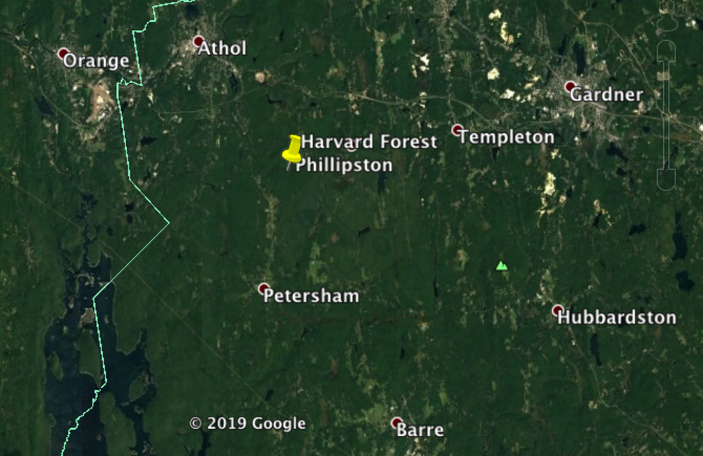

## Photosynthetic Potential

Photosynthetic potential is the capacity of primary producers of an ecosystem to fix carbon during photosynthesis depending on light and carbon availability. In the Harvard forest, this potential varies throughout the year with maximum photosynthetic potential during the summer solstice. This parameter can be derived from net ecosystem exchange and photosynthetically active radiation (PAR) data collected from trees during the day, by applying the Michaelis-Menten approach (NEE ~ (a1 * PAR * ax)/(a1 * PAR + ax) + r), which can be used to fit a light response model.

## Ecosystem Respiration

Ecosystem respiration includes the CO2 contribution of both heterotrophs and autotrophs to the atmosphere. Statistical field studies have found that temperature, soil moisture, nutrient avilability, biomass, ecosystem productivity, and season carbon allocation to be controling factors of ecosystem respiration (Urbanski et al., 2007). Temperature and respiration data collected from trees in Harvard Forest at night will be used to fit the Arrhenius model (NEE ~ a exp(b∗TA)), which fits temperature response curve to the data

# Results

## Workflow

```r
load("~/BSC6926/BSC6926/NLM_Workshop.RData")
library(nlstools)
```

### Temperature Response Curve

```
## $a
## [1] 1.791677
##
## $b
## [1] 0.038074
```

```
##
## Formula: NEE ~ (a * exp(b * TA))
##
## Parameters:
##   Estimate Std. Error t value Pr(>|t|)
## a 1.475246   0.072920   20.23   <2e-16 ***
## b 0.057088   0.003005   19.00   <2e-16 ***
## ---
## Signif. codes:  0 '***' 0.001 '**' 0.01 '*' 0.05 '.' 0.1 ' ' 1
##
## Residual standard error: 2.786 on 2007 degrees of freedom
##
## Number of iterations to convergence: 4
## Achieved convergence tolerance: 3.602e-06
##   (6410 observations deleted due to missingness)
```

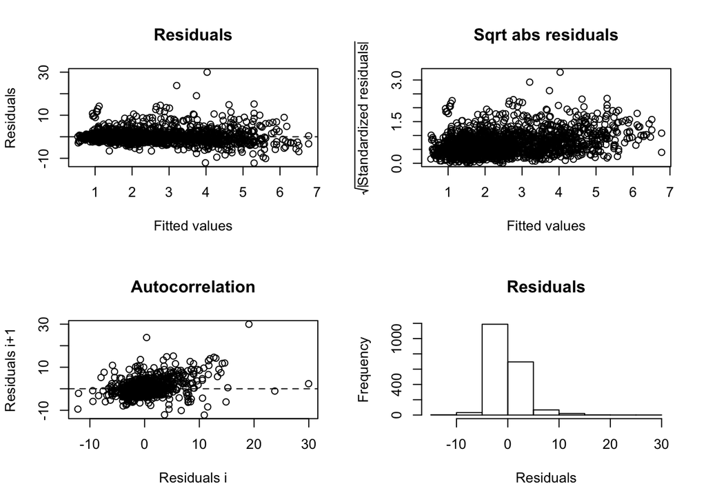

**Visual Assessment of Residuals**

```
##
## ------
## Bootstrap statistics
##     Estimate  Std. error
## a 1.48413942 0.154327136
## b 0.05678896 0.006483177
##
## ------
## Median of bootstrap estimates and percentile confidence intervals
##       Median       2.5%      97.5%
## a 1.49039673 1.18033128 1.72404388
## b 0.05638538 0.04521725 0.06874937
```

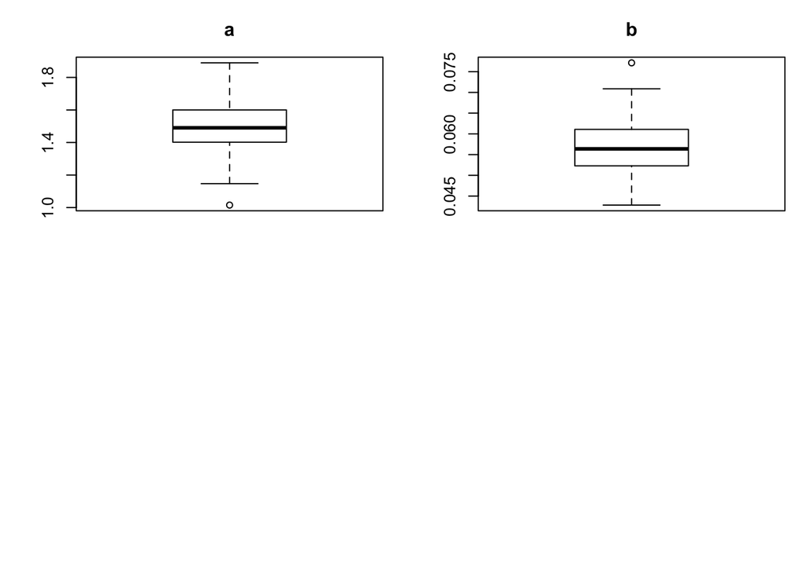

**Bootstrap estimates**

**Table: Bootstrap Error Estimations**

| MONTH | a | b | a.pvalue | b.pvalue | a.est | b.est | a.se | b.se |
| --- | --- | --- | --- | --- | --- | --- | --- | --- |
| 1 | 1.282269 | 0.02790290 | 1.517208e-220 | 3.011664e-13 | 1.283114 | 0.02847002 | 0.04347040 | 0.004991205 |
| 2 | 1.235768 | 0.03136415 | 0.000000e+00 | 1.046202e-17 | 1.231532 | 0.03133391 | 0.02503322 | 0.003826705 |
| 3 | 1.100982 | 0.03821936 | 0.000000e+00 | 3.409956e-36 | 1.097993 | 0.03803801 | 0.02692536 | 0.003482299 |
| 4 | 1.270256 | 0.04778370 | 9.388955e-119 | 1.996675e-28 | 1.281700 | 0.04670698 | 0.06079795 | 0.004702788 |
| 5 | 1.755595 | 0.05711215 | 5.909861e-83 | 1.959344e-57 | 1.765673 | 0.05688352 | 0.10007115 | 0.003954918 |
| 6 | 2.400223 | 0.03898557 | 5.736367e-21 | 1.565565e-10 | 2.418820 | 0.03896888 | 0.34018543 | 0.008184100 |
| 7 | 2.005217 | 0.04542344 | 2.136076e-11 | 4.612830e-09 | 2.065750 | 0.04455556 | 0.32043415 | 0.008015962 |
| 8 | 4.798788 | -0.01422836 | 4.284395e-10 | 1.053243e-01 | 4.796430 | -0.01318601 | 0.90388840 | 0.009986211 |
| 9 | 1.821087 | 0.03695653 | 3.276226e-23 | 2.665966e-09 | 1.803356 | 0.03811303 | 0.20229680 | 0.006971214 |
| 10 | 1.679584 | 0.03924262 | 1.563406e-84 | 7.956977e-20 | 1.686214 | 0.03847081 | 0.08930908 | 0.004804906 |
| 11 | 1.674098 | 0.05336360 | 9.939988e-262 | 3.168972e-64 | 1.675999 | 0.05357242 | 0.04840987 | 0.003599622 |
| 12 | 1.641404 | 0.03461396 | 0.000000e+00 | 5.548747e-19 | 1.641302 | 0.03381815 | 0.04021458 | 0.004711634 |

# Discussion